# Practical Machine Learning - Prediction Model for Weight Lifting Exercise Dataset

Gavin Kim

2016-12-15

## Loading data

#### Load libraries

```r
library(caret)
library(randomForest)
library(corrplot)
library(MASS)

# For increasing learning speed, use multi-core.
library(doMC)
registerDoMC(cores = 8)
```

#### Download and Load training/test data

```r
# Check existance of data directory and create it if not exist.
dataDir <- "data"
if(!dir.exists(dataDir))
  dir.create(dataDir)

# Download training and test file
Url.train <- "https://d396qusza40orc.cloudfront.net/predmachlearn/pml-training.csv"
Url.test <- "https://d396qusza40orc.cloudfront.net/predmachlearn/pml-testing.csv"
data.trainPath <- paste0(dataDir, "/", basename(Url.train))
data.testPath <- paste0(dataDir, "/", basename(Url.test))

if(!file.exists(data.trainPath))
  download.file(Url.train, data.trainPath, mode = "w")
if(!file.exists(data.testPath))
  download.file(Url.test, data.testPath, mode = "w")

data.train <- read.csv(data.trainPath)
data.test <- read.csv(data.testPath)
```

## Preprocessing data

After loaing data, we need to remove the columns what we don’t use. There are columns that have only NA values and nearly zero variance. It’s better that we could replace these columns from data and there’s columns not related to predict weight lifting exercise like observation number or user name or timestamps. It also has to be removed.

```r
# Remove columns having NA values
cs <- colSums(is.na(data.train))
data.train <- data.train[,(cs == 0)]
data.test <- data.test[,(cs == 0)]

# Remove near zero columns
nzvColumns <- nearZeroVar(data.train,saveMetrics=TRUE)
data.train <- data.train[,!nzvColumns$nzv]
data.test <- data.test[,!nzvColumns$nzv]

# Remove unnecessary columns (Username, timesstamps)
data.train <- data.train[,-c(1:6)]
data.test <- data.test[,-c(1:6)]
```

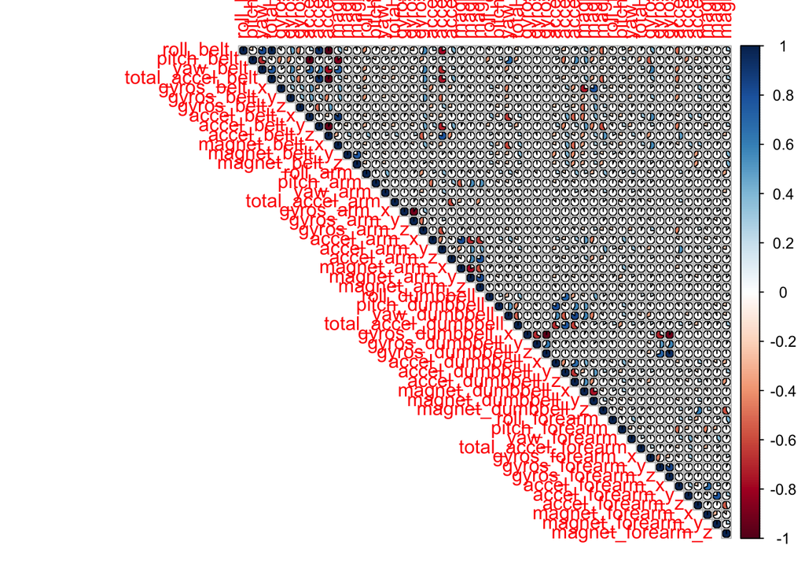

```r
corrplot(cor(data.train[,-53]), method="pie", type="upper")
```

#### Split data to training and validation set

After cleaning data, I found the test data set has only 20 observasions. It’s too small to check the accuracy of model. Hence, I decided to split training data with training and validation. The validation data is for test model’s accuracy and I’ll use training data for building model with K-fold cross validation.

```r
# split data for training/validation
inTrain <- createDataPartition(y=data.train$classe, p=0.7, list=FALSE)
data.trainPart <- data.train[inTrain,]
data.validPart <- data.train[-inTrain,]
```

## Modeling

I made plan to use ensemble model with stacking gbm, rf, ctree And PCA can reduce the size of variables for training performance.

```r
# 53th column is "classe" what will used for outcome label.
pcaModel <- preProcess(data.trainPart[,-53], method=c("pca", "center", "scale"), thresh = 0.95)
data.trainPca <- predict(pcaModel, data.trainPart[,-53])
data.trainPca <- data.frame(data.trainPca, classe = data.trainPart[,53])
data.validPca <- predict(pcaModel, data.validPart[,-53])
data.validPca <- data.frame(data.validPca, classe = data.validPart[,53])
print(pcaModel)
```

```
## Created from 13737 samples and 52 variables
##
## Pre-processing:
##   - centered (52)
##   - ignored (0)
##   - principal component signal extraction (52)
##   - scaled (52)
##
## PCA needed 25 components to capture 95 percent of the variance
```

As you see above 25 components has captured with 95 percent of the variance.

```r
set.seed(1234)
fit_gbm <- train(classe ~ ., data = data.trainPca, method = "gbm")
pred_gbm <- predict(fit_gbm, newdata = data.validPca)
confusionMatrix(pred_gbm,data.validPca$classe)
```

```
## Confusion Matrix and Statistics
##
##           Reference
## Prediction    A    B    C    D    E
##          A 1504  122   40   40   28
##          B   35  845   92   22   81
##          C   51  106  847  103   56
##          D   70   26   28  784   56
##          E   14   40   19   15  861
##
## Overall Statistics
##
##                Accuracy : 0.8226
##                  95% CI : (0.8126, 0.8323)
##     No Information Rate : 0.2845
##     P-Value [Acc > NIR] : < 2.2e-16
##
##                   Kappa : 0.7754
##  Mcnemar's Test P-Value : < 2.2e-16
##
## Statistics by Class:
##
##                      Class: A Class: B Class: C Class: D Class: E
## Sensitivity            0.8984   0.7419   0.8255   0.8133   0.7957
## Specificity            0.9454   0.9515   0.9350   0.9634   0.9817
## Pos Pred Value         0.8674   0.7860   0.7283   0.8133   0.9073
## Neg Pred Value         0.9590   0.9389   0.9621   0.9634   0.9552
## Prevalence             0.2845   0.1935   0.1743   0.1638   0.1839
## Detection Rate         0.2556   0.1436   0.1439   0.1332   0.1463
## Detection Prevalence   0.2946   0.1827   0.1976   0.1638   0.1613
## Balanced Accuracy      0.9219   0.8467   0.8803   0.8884   0.8887
```

```r
set.seed(1234)
fit_rf <- train(classe ~ ., data = data.trainPca, method = "rf")
pred_rf <- predict(fit_rf, newdata = data.validPca)
confusionMatrix(pred_rf,data.validPca$classe)
```

```
## Confusion Matrix and Statistics
##
##           Reference
## Prediction    A    B    C    D    E
##          A 1661   14    2    0    0
##          B    3 1115   18    0    7
##          C    5    9  999   35    6
##          D    2    0    7  927   11
##          E    3    1    0    2 1058
##
## Overall Statistics
##
##                Accuracy : 0.9788
##                  95% CI : (0.9747, 0.9823)
##     No Information Rate : 0.2845
##     P-Value [Acc > NIR] : < 2.2e-16
##
##                   Kappa : 0.9731
##  Mcnemar's Test P-Value : NA
##
## Statistics by Class:
##
##                      Class: A Class: B Class: C Class: D Class: E
## Sensitivity            0.9922   0.9789   0.9737   0.9616   0.9778
## Specificity            0.9962   0.9941   0.9887   0.9959   0.9988
## Pos Pred Value         0.9905   0.9755   0.9478   0.9789   0.9944
## Neg Pred Value         0.9969   0.9949   0.9944   0.9925   0.9950
## Prevalence             0.2845   0.1935   0.1743   0.1638   0.1839
## Detection Rate         0.2822   0.1895   0.1698   0.1575   0.1798
## Detection Prevalence   0.2850   0.1942   0.1791   0.1609   0.1808
## Balanced Accuracy      0.9942   0.9865   0.9812   0.9788   0.9883
```

```r
set.seed(1234)
fit_ctree <- train(classe ~ ., data = data.trainPca, method = "ctree")
pred_ctree <- predict(fit_ctree, newdata = data.validPca)
confusionMatrix(pred_ctree,data.validPca$classe)
```

```
## Confusion Matrix and Statistics
##
##           Reference
## Prediction    A    B    C    D    E
##          A 1442   95   73   48   55
##          B   99  825  103   45   78
##          C   55   73  733   65   52
##          D   40   46   46  746   54
##          E   38  100   71   60  843
##
## Overall Statistics
##
##                Accuracy : 0.7798
##                  95% CI : (0.769, 0.7903)
##     No Information Rate : 0.2845
##     P-Value [Acc > NIR] : < 2e-16
##
##                   Kappa : 0.7211
##  Mcnemar's Test P-Value : 0.02257
##
## Statistics by Class:
##
##                      Class: A Class: B Class: C Class: D Class: E
## Sensitivity            0.8614   0.7243   0.7144   0.7739   0.7791
## Specificity            0.9356   0.9315   0.9496   0.9622   0.9440
## Pos Pred Value         0.8418   0.7174   0.7495   0.8004   0.7581
## Neg Pred Value         0.9444   0.9337   0.9403   0.9560   0.9499
## Prevalence             0.2845   0.1935   0.1743   0.1638   0.1839
## Detection Rate         0.2450   0.1402   0.1246   0.1268   0.1432
## Detection Prevalence   0.2911   0.1954   0.1662   0.1584   0.1890
## Balanced Accuracy      0.8985   0.8279   0.8320   0.8680   0.8616
```

```r
predDF <- data.frame(pred_gbm, pred_rf, pred_ctree, classe = data.validPca$classe)
fit_stacked <- train(classe ~ ., data = predDF, method="rf")
pred_stacked <- predict(fit_stacked, newdata = predDF)
confusionMatrix(pred_stacked,data.validPca$classe)
```

```
## Confusion Matrix and Statistics
##
##           Reference
## Prediction    A    B    C    D    E
##          A 1661   14    2    0    0
##          B    3 1115   18    0    7
##          C    5    9  999   35    6
##          D    2    0    7  927   11
##          E    3    1    0    2 1058
##
## Overall Statistics
##
##                Accuracy : 0.9788
##                  95% CI : (0.9747, 0.9823)
##     No Information Rate : 0.2845
##     P-Value [Acc > NIR] : < 2.2e-16
##
##                   Kappa : 0.9731
##  Mcnemar's Test P-Value : NA
##
## Statistics by Class:
##
##                      Class: A Class: B Class: C Class: D Class: E
## Sensitivity            0.9922   0.9789   0.9737   0.9616   0.9778
## Specificity            0.9962   0.9941   0.9887   0.9959   0.9988
## Pos Pred Value         0.9905   0.9755   0.9478   0.9789   0.9944
## Neg Pred Value         0.9969   0.9949   0.9944   0.9925   0.9950
## Prevalence             0.2845   0.1935   0.1743   0.1638   0.1839
## Detection Rate         0.2822   0.1895   0.1698   0.1575   0.1798
## Detection Prevalence   0.2850   0.1942   0.1791   0.1609   0.1808
## Balanced Accuracy      0.9942   0.9865   0.9812   0.9788   0.9883
```

The model what has best performance is Random forest as you see. And the ensemble model of gbm, rf, ctree gets no benefit of accuracy.

## Testing

We need answer to predict the 20 test set with this model. Here is the results.

```r
# Apply PCA
data.testPCA <- predict(pcaModel, data.test[,-53])

# Create predicted variales
pred_gbm_test <- predict(fit_gbm, newdata = data.testPCA)
pred_rf_test <- predict(fit_rf, newdata = data.testPCA)
pred_ctree_test <- predict(fit_ctree, newdata = data.testPCA)

predDF_test <- data.frame(pred_gbm = pred_gbm_test, pred_rf = pred_rf_test, pred_ctree = pred_ctree_test)
pred_stacked_test <- predict(fit_stacked, newdata = predDF_test)
print(t(data.frame(pred_stacked_test)))
```

```
##                   [,1] [,2] [,3] [,4] [,5] [,6] [,7] [,8] [,9] [,10] [,11]
## pred_stacked_test "B"  "A"  "C"  "A"  "A"  "E"  "D"  "B"  "A"  "A"   "A"
##                   [,12] [,13] [,14] [,15] [,16] [,17] [,18] [,19] [,20]
## pred_stacked_test "C"   "B"   "A"   "E"   "E"   "A"   "B"   "B"   "B"
```